# Vignette_6: Data Inference with human study: AD vs Control classes

# StellarPath

- This vignette focuses on inferring the class of new patients after that StellarPath has been trained with previous ones.
- This vignette is useful when you trained and tested StellarPath on a known dataset and you want to use the predictive markers to predict the class of the patients described in a external dataset.

## Note

Before checking this vignette, we suggest to go through the first and second vignette describing the main workflow. This vignette is advanced, we will skip the explanations about operations and data, we will focus on the inference operation and results only.

## Case study

For this vignette, StellarPath is applied on a simple experimental study:

- We have: Human samples divided into Alzheimer’s disease and Control
- We have: Two indipendent RNA sequencing datasets
- We want: Find deregulated molecules, pathways and predictive pathways-specific PSNs between AD and Control patients in one known dataset
- We want: Use the predictive pathways-specific PSNs to predict the class of new patients described in new datasets coming from indipendent studies

# Enviroment set up

Let us clean the R enviroment, set the working directory, load the software package, set the random seed generator for reproducing always the same results and define the number of cores available in the computer to run the operations.

- Be careful: set up the number of cores based on your resources, if you are not secure how to, then just set equal to 2

```r
#Clean workspace and memory ----
rm(list=ls())
gc()
```

```
#>          used (Mb) gc trigger (Mb) max used (Mb)
#> Ncells 510538 27.3    1125888 60.2   665582 35.6
#> Vcells 936678  7.2    8388608 64.0  1819332 13.9
```

```r
#Set working directory ----
gps0=getwd()
gps0=paste(gps0,"/%s",sep="")
rootDir=gps0
setwd(gsub("%s","",rootDir))
set.seed(5)

#Load libraries ----
library("StellarPath")
SP_initialize()
```

```
#> Bioconductor version '3.14' is out-of-date; the current release version '3.17'
#>   is available with R version '4.3'; see https://bioconductor.org/install
#>
#> This is StellarPath (version 1.9.0) .
#> StellarPath is new and still rapidly improving.
#>
#> Newer versions will improve functions and increase the omics which the software can process.
#>
#> Please send us feedback based on your experience.
```

```r
library("qs")
library("data.table")
```

```r
library("ggplot2")
library("plyr")
library("ggpubr")
library("writexl")
library("biomaRt")

#' Convert ensemble gene names to gene symbols
#'
#' This function takes a vector of ensemble gene names and converts them to gene symbols using the Ensembl database. It retrieves the corresponding gene symbols and returns them as a named vector.
#'
#' @param ensemble_names A vector of ensemble gene names
#' @importFrom biomaRt useMart
#' @importFrom biomaRt getBM
#' @importFrom plyr mapvalues
#' @return A named vector of gene symbols corresponding to the ensemble gene names
#' @examples
#' ensemble_names <- c("ENSG00000149313", "ENSG00000139618", "ENSG00000105829")
#' gene_symbols <- convert_ens2symbol(ensemble_names)
#' print(gene_symbols)
#' @export
convert_ens2symbol <- function(ensemble_names) {
  # Connect to the Ensembl database using the human dataset
  ensembl <- biomaRt::useMart("ensembl", dataset = "hsapiens_gene_ensembl",  host="https://useast.ensembl.org")

  # Get the gene symbols corresponding to the ensemble gene names
  gene_symbols <- biomaRt::getBM(
    attributes = c("ensembl_gene_id", "external_gene_name"),
    filters = "ensembl_gene_id",
    values = ensemble_names,
    mart = ensembl
  )

  gene_symbols=plyr::mapvalues(ensemble_names,from = gene_symbols$ensembl_gene_id,to=gene_symbols$external_gene_name)

  # Return a named vector of gene symbols
  return(gene_symbols)
}


#Set variables ----
#Input
#Set the number of cores available in the system
n_cores=15
#output
#Set the output file where all the data and results will be stored in the end
out_res_path="classif_AD.qs"
out_plot_path="classif_AD.pdf"
out_perfs_path="classif_AD.xlsx"
```

# Data set up

StellarPath is a binary classifier and works with one or multiple omics from high-throughput sequencing describing the two patient classes in comparison. For this vignette, we load the human data describing AD patients that StellarPath extracts and prepares from Recount3 database.

```r
#Load and set up the example data ----

srp86=recount3::create_rse_manual(
  project = "SRP181886",
  project_home = "data_sources/sra",
  organism = "human",
  annotation = "gencode_v29",
  type = "gene"
)
```

```
#> 2023-08-17 13:05:35 downloading and reading the metadata.
#> 2023-08-17 13:05:36 caching file sra.sra.SRP181886.MD.gz.
#> 2023-08-17 13:05:37 caching file sra.recount_project.SRP181886.MD.gz.
#> 2023-08-17 13:05:38 caching file sra.recount_qc.SRP181886.MD.gz.
#> 2023-08-17 13:05:39 caching file sra.recount_seq_qc.SRP181886.MD.gz.
#> 2023-08-17 13:05:41 caching file sra.recount_pred.SRP181886.MD.gz.
#> 2023-08-17 13:05:41 downloading and reading the feature information.
#> 2023-08-17 13:05:42 caching file human.gene_sums.G029.gtf.gz.
#> 2023-08-17 13:05:43 downloading and reading the counts: 289 samples across 64837 features.
#> 2023-08-17 13:05:44 caching file sra.gene_sums.SRP181886.G029.gz.
#> 2023-08-17 13:05:48 construcing the RangedSummarizedExperiment (rse) object.
```

```r
counts1=srp86@assays@data@listData[["raw_counts"]]
info1=as.data.frame(srp86@colData)
info1=info1[,seq(1,42)]
sample_id=info1$external_id

# Prepare gene expression matrix
gene_names=convert_ens2symbol(remove_ending(rownames(counts1)))
keep=sapply(gene_names,nchar)>1
counts1=counts1[keep,]
gene_names=gene_names[keep]
rownames(counts1)=gene_names
counts1=remove_duplicates(counts1,gene_names)

# Prepare info dataframe
info1=create_df4attr(info1$sra.sample_attributes)
info1$sample_id=sample_id

srp48=recount3::create_rse_manual(
  project = "SRP100948",
  project_home = "data_sources/sra",
  organism = "human",
  annotation = "gencode_v29",
  type = "gene"
)
```

```
#> 2023-08-17 13:10:12 downloading and reading the metadata.
#> 2023-08-17 13:10:13 caching file sra.sra.SRP100948.MD.gz.
#> 2023-08-17 13:10:14 caching file sra.recount_project.SRP100948.MD.gz.
#> 2023-08-17 13:10:15 caching file sra.recount_qc.SRP100948.MD.gz.
#> 2023-08-17 13:10:16 caching file sra.recount_seq_qc.SRP100948.MD.gz.
#> 2023-08-17 13:10:17 caching file sra.recount_pred.SRP100948.MD.gz.
#> 2023-08-17 13:10:17 downloading and reading the feature information.
#> 2023-08-17 13:10:18 caching file human.gene_sums.G029.gtf.gz.
#> 2023-08-17 13:10:19 downloading and reading the counts: 117 samples across 64837 features.
#> 2023-08-17 13:10:20 caching file sra.gene_sums.SRP100948.G029.gz.
#> 2023-08-17 13:10:20 construcing the RangedSummarizedExperiment (rse) object.
```

```r
counts2=srp48@assays@data@listData[["raw_counts"]]
info2=as.data.frame(srp48@colData)
info2=info2[,seq(1,42)]
sample_id=info2$external_id

# Prepare gene expression matrix
gene_names=convert_ens2symbol(remove_ending(rownames(counts2)))
keep=sapply(gene_names,nchar)>1
counts2=counts2[keep,]
gene_names=gene_names[keep]
rownames(counts2)=gene_names
counts2=remove_duplicates(counts2,gene_names)

# Prepare info dataframe
info2=create_df4attr(info2$sra.sample_attributes)
info2$sample_id=sample_id

# Harmonize the two dataframes and check with counts
info1=info1[,c(7,3,1,4)]
info2=info2[,c(6,3,1,7)]
colnames(info1)=colnames(info2)=c("ID","Status","Age","Sex")
info1$Status[info1$Status!="control"]="AD"
counts1=as.matrix(counts1[,info1$ID])
info2$Status[info2$Status!="control"]="AD"
counts2=as.matrix(counts2[,info2$ID])
```

# Training and Testing

Here, we train and test StellarPath on the largest AD vs Control dataset. We run the main workflow based on cross-validation.

```r
#Set name of the project, the specie id of the samples, the name of the classes to compare (case vs control)
name_dataset="ADvsC"
tax_id=9606
groups=c("AD","control")

data_l=prepare_data(info = info1[,c(1,2)],
                    groups_name = groups,
                    gex = counts1,
                    tax_id = tax_id,
                    n_cores = n_cores);tmp=gc();
```

```
#> Checking input omics/raw count matrices
#> >gene expression data (genes per samples) found
#> Checking input info
#> >dataframe format
#> >two columns
#> >does NOT contain NA values
#> >groups in comparison are two
#> >second column of info contains only labels which belong to the user defined group's names
#> Checking same sample's IDs between info first column and omics column names
#> >same order of existing samples between info dataframe and omics data
#> Checking format of input omics
#> >omics are in the same format
#> >omics are matrices
#> Ordering samples based on groups
#> >The comparison and classification is with:
#> >>first group : AD of samples: 219
#> >>second group : control of samples: 70
#> Simplifying sample's names in info and omics data
#> >>from: SRR8482617 to: AD.1
#> >>original sample's IDs remain as rownames of the info dataframe
#> Loading human databases
#> Processing and Normalizing omics
#> >preparing gex
#> >>number of genes falling into pathways: 17537
#> >>number of lncRNAs having target sets of genes: 1259
#> Preparing partitions of data for cross validation setting
```

```r
#Find the pathways that in the training data produce a significant PSN
data_l=analyse_training(data_l)
```

```
#> >using the following cores: 15
#> Feature selection of training data belonging to: 1 run of cross validation
#> >training samples:
#> >>first group: AD of training samples: 157
#> >>second group: control of training samples: 50
#> >analysis:
#> >>finding differentially expressed genes
#> >>finding enriched pathways represented by a significant PSN
#> >finding differentially expressed lncRNAs
#> >>finding enriched lncRNA's gene targets passing ecdf test
#> >>finding enriched lncRNA's gene targets represented by a significant PSN
#> >>finding enriched lncRNA's miRNA targets passing ecdf test
#> >>finding enriched lncRNA's miRNA targets represented by a significant PSN
#> >adding significant pathways/targets/PSNs into $training$pathway_analysis
#> Feature selection of training data belonging to: 2 run of cross validation
#> >training samples:
#> >>first group: AD of training samples: 158
#> >>second group: control of training samples: 50
#> >analysis:
#> >>finding differentially expressed genes
#> >>finding enriched pathways represented by a significant PSN
#> >finding differentially expressed lncRNAs
#> >>finding enriched lncRNA's gene targets passing ecdf test
#> >>finding enriched lncRNA's gene targets represented by a significant PSN
#> >>finding enriched lncRNA's miRNA targets passing ecdf test
#> >>finding enriched lncRNA's miRNA targets represented by a significant PSN
#> >adding significant pathways/targets/PSNs into $training$pathway_analysis
```

```r
#Classify the testing patients based on the features/pathways learnt from the training
data_l=classify_testing(data_l)
```

```
#> MCC score of the run: 1 is: 1
#> Updating $testing$classification in testing data list
#> MCC score of the run: 2 is: 1
#> Updating $testing$classification in testing data list
```

```r
#Retrieve best pathways/target sets and their PSNs used in the classification
data_l=enrichment_analysis(data_l)
```

```
#> Enrichment with predictions of the run: 1 of cross validation with best performances
#> >using the following cores: 15
#> Feature selection of training data belonging to: 1 run of cross validation
#> >training samples:
#> >>first group: AD of training samples: 219
#> >>second group: control of training samples: 70
#> >analysis:
#> >>finding differentially expressed genes
#> >>finding enriched pathways represented by a significant PSN
#> >finding differentially expressed lncRNAs
#> >>finding enriched lncRNA's gene targets passing ecdf test
#> >>finding enriched lncRNA's gene targets represented by a significant PSN
#> >>finding enriched lncRNA's miRNA targets passing ecdf test
#> >>finding enriched lncRNA's miRNA targets represented by a significant PSN
#> >adding significant pathways/targets/PSNs into $training$pathway_analysis
```

```r
qsave(data_l,file=out_res_path,nthreads = 15)
```

# Training results

We have a look to the predictive and significant pathways/PSNs found between AD and Control classes.

Alzheimer’s disease (AD) is a neurodegenerative disorder characterized by the accumulation of extracellular amyloid-β (Aβ) and neurofibrillary tangles, leading to progressive synaptic and neuronal dysfunction [10]. StellarPath identified pathways that match and explain AD’s key mechanisms. The JAK/STAT signaling pathway promotes neuroinflammation in neurodegenerative diseases such as Alzheimer [1] [6] [14]. The pathway known as POSITIVE REGULATION OF INNATE IMMUNE RESPONSE plays a role in the innate immune system and neuroinflammation in AD’s pathogenesis [2] [7] [12]. The REGULATION OF SEQUESTERING OF CALCIUM ION pathway reveals that intracellular calcium regulation is vital for the proper cellular viability, and its dysregulation is a hallmark of AD [3] [8] [13]. The NEGATIVE REGULATION OF CELL-CELL ADHESION pathway affects how brain cells connect, contributing to the neuronal disruption observed in AD [4] [15]. Even the HALLMARK_ALLOGRAFT_REJECTION pathway is indirectly connected to the immune system when AD is deregulating [5]. Together, these pathways describe a coherent picture of how AD acts at the cellular level, where immune response, calcium balance, and cell connections are involved.

[1] https://www.ncbi.nlm.nih.gov/pmc/articles/PMC9821184/ [2] https://www.ncbi.nlm.nih.gov/pmc/articles/PMC7954128/ [3] https://www.ncbi.nlm.nih.gov/pmc/articles/PMC7699688/ [4] https://www.ncbi.nlm.nih.gov/pmc/articles/PMC6065556/ [5] https://www.ncbi.nlm.nih.gov/pmc/articles/PMC8830081/ [6] https://pubmed.ncbi.nlm.nih.gov/36614305/ [7] https://www.ncbi.nlm.nih.gov/pmc/articles/PMC7783860/ [8] https://www.ncbi.nlm.nih.gov/pmc/articles/PMC8124842/ [9] https://www.ncbi.nlm.nih.gov/pmc/articles/PMC1876750/ [10] https://www.ncbi.nlm.nih.gov/pmc/articles/PMC2941917/ [11] https://www.nature.com/articles/s41392-021-00791-1 [12] https://journals.sagepub.com/doi/full/10.1177/17590914211051908 [13] https://www.sciencedirect.com/science/article/pii/S2222180814606666 [14] https://journals.sagepub.com/doi/10.1177/09727531211070532?icid=int.sj-full-text.similar-articles.7 [15] https://doi.org/10.2147/DNND.S19829

```r
paths_df=data_l$enrichment$pathway_analysis$top_pathways_df
knitr::kable(paths_df[,1:9])
```

|  | pathways | freq | sign_type | regulation | group | power | min_intra_STRONG | max_intra_WEAK | max_inter_similarities |
| --- | --- | --- | --- | --- | --- | --- | --- | --- | --- |
| 3 | Calcium signaling pathway | 6 | -1 | inhibited | AD | 7 | 0.4243092 | 0.2716343 | 0.4203138 |
| 11 | FEAR RESPONSE | 4 | -1 | inhibited | AD | 7 | 0.4686450 | 0.2393099 | 0.4557032 |
| 12 | FEAR RESPONSE | 4 | -1 | inhibited | AD | 7 | 0.4686450 | 0.2393099 | 0.4557032 |
| 43 | SENSORY PERCEPTION OF PAIN | 4 | -1 | inhibited | AD | 7 | 0.4665322 | 0.2602176 | 0.4580216 |
| 20 | Jak-STAT signaling pathway | 3 | 1 | activated | AD | 7 | 0.6011870 | 0.4225170 | 0.5871353 |
| 26 | NEGATIVE REGULATION OF CELL-CELL ADHESION | 3 | 1 | activated | AD | 7 | 0.6543463 | 0.3662459 | 0.5360740 |
| 35 | POSITIVE REGULATION OF PHOSPHATIDYLINOSITOL 3-KINASE SIGNALING | 3 | -1 | inhibited | AD | 7 | 0.5038772 | 0.2393015 | 0.4964947 |
| 41 | REGULATION OF PHOSPHATIDYLINOSITOL 3-KINASE SIGNALING | 3 | -1 | inhibited | AD | 7 | 0.5038772 | 0.2393015 | 0.4964947 |
| 1 | Amoebiasis | 4 | -2 | inhibited | control | 6 | 0.5310034 | 0.3538976 | 0.5279154 |
| 2 | Amoebiasis | 4 | -2 | inhibited | control | 6 | 0.5310034 | 0.3538976 | 0.5279154 |
| 44 | SEROTONIN RECEPTOR SIGNALING PATHWAY | 4 | -1 | inhibited | AD | 6 | 0.4523702 | 0.2405572 | 0.3806203 |
| 7 | CELLULAR DEFENSE RESPONSE | 3 | -1 | inhibited | AD | 6 | 0.4553158 | 0.1875475 | 0.4461130 |
| 9 | CHEMOKINE-MEDIATED SIGNALING PATHWAY | 3 | -2 | inhibited | control | 6 | 0.5441504 | 0.3265959 | 0.4567024 |
| 13 | Gap junction | 3 | -1 | inhibited | AD | 6 | 0.5002353 | 0.2315373 | 0.4856078 |
| 15 | HALLMARK_COMPLEMENT | 3 | -2 | inhibited | control | 6 | 0.4842361 | 0.3003150 | 0.4774553 |
| 16 | HALLMARK_COMPLEMENT | 3 | -2 | inhibited | control | 6 | 0.4842361 | 0.3003150 | 0.4774553 |
| 28 | PID_IL12_2PATHWAY | 3 | 1 | activated | AD | 6 | 0.6397697 | 0.3692497 | 0.5238845 |
| 29 | POSITIVE REGULATION OF CILIUM-DEPENDENT CELL MOTILITY | 3 | -1 | inhibited | AD | 6 | 0.4368368 | 0.2023241 | 0.4362891 |
| 38 | REGULATION OF CILIUM-DEPENDENT CELL MOTILITY | 3 | -1 | inhibited | AD | 6 | 0.4368368 | 0.2023241 | 0.4362891 |
| 19 | HALLMARK_TNFA_SIGNALING_VIA_NFKB | 5 | -2 | inhibited | control | 5 | 0.4538783 | 0.2944316 | 0.4470905 |
| 14 | HALLMARK_ALLOGRAFT_REJECTION | 4 | 1 | activated | AD | 5 | 0.5431778 | 0.3425319 | 0.5394879 |
| 17 | HALLMARK_EPITHELIAL_MESENCHYMAL_TRANSITION | 4 | -2 | inhibited | control | 5 | 0.4598745 | 0.2851746 | 0.4506719 |
| 27 | NEGATIVE REGULATION OF WNT SIGNALING PATHWAY | 4 | -2 | inhibited | control | 5 | 0.4729143 | 0.3157573 | 0.4721488 |
| 5 | CELL-MATRIX ADHESION | 3 | -2 | inhibited | control | 5 | 0.3825994 | 0.2376612 | 0.3793733 |
| 6 | CELL-SUBSTRATE ADHESION | 3 | -2 | inhibited | control | 5 | 0.3825994 | 0.2376612 | 0.3793733 |
| 8 | Chemokine signaling pathway | 3 | -2 | inhibited | control | 5 | 0.5175568 | 0.3785398 | 0.5171125 |
| 18 | HALLMARK_INFLAMMATORY_RESPONSE | 3 | -2 | inhibited | control | 5 | 0.4545355 | 0.2807378 | 0.4295638 |
| 22 | MAST CELL ACTIVATION | 3 | -2 | inhibited | control | 5 | 0.4424217 | 0.2961047 | 0.4411249 |
| 23 | MYELOID LEUKOCYTE ACTIVATION | 3 | -2 | inhibited | control | 5 | 0.4424217 | 0.2961047 | 0.4411249 |
| 24 | MYELOID LEUKOCYTE ACTIVATION | 3 | -2 | inhibited | control | 5 | 0.4424217 | 0.2961047 | 0.4411249 |
| 30 | POSITIVE REGULATION OF INFLAMMATORY RESPONSE | 3 | -2 | inhibited | control | 5 | 0.4453560 | 0.2879884 | 0.4432748 |
| 31 | POSITIVE REGULATION OF INFLAMMATORY RESPONSE | 3 | -2 | inhibited | control | 5 | 0.4453560 | 0.2879884 | 0.4432748 |
| 32 | POSITIVE REGULATION OF INNATE IMMUNE RESPONSE | 3 | 1 | activated | AD | 5 | 0.5587868 | 0.4110408 | 0.5470350 |
| 33 | POSITIVE REGULATION OF MAP KINASE ACTIVITY | 3 | -1 | inhibited | AD | 5 | 0.4707378 | 0.2271293 | 0.4587666 |
| 34 | POSITIVE REGULATION OF MAP KINASE ACTIVITY | 3 | -1 | inhibited | AD | 5 | 0.4707378 | 0.2271293 | 0.4587666 |
| 37 | REGULATION OF BMP SIGNALING PATHWAY | 3 | -2 | inhibited | control | 5 | 0.4411133 | 0.2957460 | 0.4400000 |
| 39 | REGULATION OF MAP KINASE ACTIVITY | 3 | -1 | inhibited | AD | 5 | 0.4707378 | 0.2271293 | 0.4587666 |
| 40 | REGULATION OF MAP KINASE ACTIVITY | 3 | -1 | inhibited | AD | 5 | 0.4707378 | 0.2271293 | 0.4587666 |
| 42 | REGULATION OF SEQUESTERING OF CALCIUM ION | 3 | 1 | activated | AD | 5 | 0.5557329 | 0.4087554 | 0.5334834 |
| 4 | CELL ACTIVATION INVOLVED IN IMMUNE RESPONSE | 3 | -2 | inhibited | control | 4 | 0.4185425 | 0.2629658 | 0.4159908 |
| 10 | EXCRETION | 3 | -1 | inhibited | AD | 4 | 0.3570657 | 0.2140157 | 0.3501886 |
| 21 | LEUKOCYTE ACTIVATION INVOLVED IN IMMUNE RESPONSE | 3 | -2 | inhibited | control | 4 | 0.4185425 | 0.2629658 | 0.4159908 |
| 25 | NEGATIVE REGULATION OF CANONICAL WNT SIGNALING PATHWAY | 3 | -2 | inhibited | control | 4 | 0.5165076 | 0.3451481 | 0.4008682 |
| 36 | POSITIVE REGULATION OF WNT SIGNALING PATHWAY | 3 | -2 | inhibited | control | 3 | 0.3300070 | 0.2244161 | 0.3288834 |

```r
write.table(paths_df$pathways[paths_df$regulation=="activated" & paths_df$group==groups[1]],
            file = "AD_act.txt",quote = FALSE,row.names = FALSE,col.names = FALSE)
write.table(paths_df$pathways[paths_df$regulation!="activated" & paths_df$group==groups[1]],
            file = "AD_inh.txt",quote = FALSE,row.names = FALSE,col.names = FALSE)
```

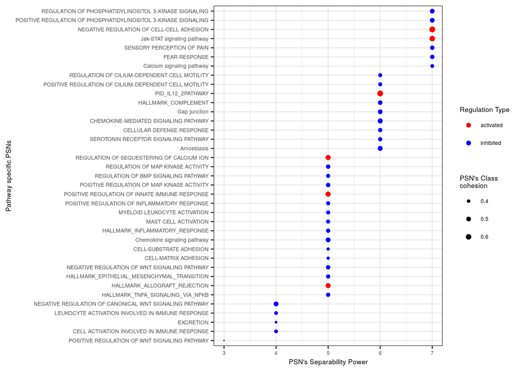

```r
x=data_l$enrichment$pathway_analysis$top_pathways_df
x=unique(x[order(x$power),1:12])
x$pathways=factor(x$pathways,ordered = TRUE,levels = x$pathways)
x=na.omit(x)

#Create plot
cv_paths_p=ggplot(x, aes(y=pathways, x=power, color=regulation, size=min_intra_STRONG)) +
  geom_point() + theme_bw() +
  scale_color_manual(breaks = c("activated", "inhibited"), values=c("red", "blue")) +
  labs(x="PSN's Separability Power", y="Pathway specific PSNs",
       color="Regulation Type", size="PSN's Class\ncohesion") +
  theme(text = element_text(size=6.5)) +
  scale_size(range = c(0, 2))

#Visualize
cv_paths_p
```

# Inference

We now introduce external datasets with different patients. We combine the datasets (info and count matrices). We define the IDs of the patients previously used as training and the new ones to be predicted. We feed the prepared data to the function infer_new_data.

```r
#Assemble old and new data which patients' class must be infer
info=rbind(info1[,c(1,2)],info2[,c(1,2)])
gex=cbind(counts1,counts2)

#Prepare the run's data to predict the class of specifically the new patients
user_sets=list()
user_sets[[1]]=list(train=info1[,1],test=info2[,1])

data_l=infer_new_data(info,
                      groups_name=groups,
                      gex=gex,
                      tax_id=tax_id,
                      user_sets=user_sets,
                      data_l=data_l,
                      n_cores=n_cores)
```

```
#> Checking input omics/raw count matrices
#> >gene expression data (genes per samples) found
#> Checking input info
#> >dataframe format
#> >two columns
#> >does NOT contain NA values
#> >groups in comparison are two
#> >second column of info contains only labels which belong to the user defined group's names
#> Checking same sample's IDs between info first column and omics column names
#> >same order of existing samples between info dataframe and omics data
#> Checking format of input omics
#> >omics are in the same format
#> >omics are matrices
#> Ordering samples based on groups
#> >The comparison and classification is with:
#> >>first group : AD of samples: 303
#> >>second group : control of samples: 103
#> Simplifying sample's names in info and omics data
#> >>from: SRR8482617 to: AD.1
#> >>original sample's IDs remain as rownames of the info dataframe
#> Loading human databases
#> Processing and Normalizing omics
#> >preparing gex
#> >>number of genes falling into pathways: 17537
#> >>number of lncRNAs having target sets of genes: 1259
#> Preparing partitions of data for cross validation setting
#> >>User's defined trained and testing/blind patients set correctly
#> >using the following cores: 15
#> Feature selection of training data belonging to: 1 run of cross validation
#> >training samples:
#> >>first group: AD of training samples: 197
#> >>second group: control of training samples: 63
#> >analysis:
#> >>finding differentially expressed genes
#> >>finding enriched pathways represented by a significant PSN
#> >finding differentially expressed lncRNAs
#> >>finding enriched lncRNA's gene targets passing ecdf test
#> >>finding enriched lncRNA's gene targets represented by a significant PSN
#> >>finding enriched lncRNA's miRNA targets passing ecdf test
#> >>finding enriched lncRNA's miRNA targets represented by a significant PSN
#> >adding significant pathways/targets/PSNs into $training$pathway_analysis
#> MCC score of the run: 1 is: 1
#> Updating $testing$classification in testing data list
#> Enrichment with predictions of the run: 1 of cross validation with best performances
#> >using the following cores: 15
#> Feature selection of training data belonging to: 1 run of cross validation
#> >training samples:
#> >>first group: AD of training samples: 303
#> >>second group: control of training samples: 103
#> >analysis:
#> >>finding differentially expressed genes
#> >>finding enriched pathways represented by a significant PSN
#> >finding differentially expressed lncRNAs
#> >>finding enriched lncRNA's gene targets passing ecdf test
#> >>finding enriched lncRNA's gene targets represented by a significant PSN
#> >>finding enriched lncRNA's miRNA targets passing ecdf test
#> >>finding enriched lncRNA's miRNA targets represented by a significant PSN
#> >adding significant pathways/targets/PSNs into $training$pathway_analysis
```

```r
#Save results
qsave(data_l,file = out_res_path, nthreads = n_cores)
```

# Inference results

We watch the predictions made for the new patients

```r
#Info dataframe including the patients meta-information
new_pats_indxs=grep("SRR53*",rownames(data_l$inference$run1$testing$info))
knitr::kable(data_l$inference$run1$testing$info[new_pats_indxs,])
```

|  | IDs | Groups | val_indxs | test_indxs | train_indxs | val_preds | test_preds | likelihood |
| --- | --- | --- | --- | --- | --- | --- | --- | --- |
| SRR5305477 | AD.219 | AD | 0 | 1 | 0 | not_used | AD | 100.0 |
| SRR5305478 | AD.220 | AD | 0 | 1 | 0 | not_used | AD | 100.0 |
| SRR5305479 | AD.221 | AD | 0 | 1 | 0 | not_used | AD | 100.0 |
| SRR5305481 | AD.222 | AD | 0 | 1 | 0 | not_used | AD | 100.0 |
| SRR5305482 | AD.223 | AD | 0 | 1 | 0 | not_used | AD | 100.0 |
| SRR5305484 | AD.224 | AD | 0 | 1 | 0 | not_used | AD | 100.0 |
| SRR5305485 | AD.225 | AD | 0 | 1 | 0 | not_used | AD | 100.0 |
| SRR5305486 | AD.226 | AD | 0 | 1 | 0 | not_used | AD | 100.0 |
| SRR5305487 | AD.227 | AD | 0 | 1 | 0 | not_used | AD | 100.0 |
| SRR5305488 | AD.228 | AD | 0 | 1 | 0 | not_used | AD | 100.0 |
| SRR5305489 | AD.229 | AD | 0 | 1 | 0 | not_used | AD | 100.0 |
| SRR5305491 | AD.230 | AD | 0 | 1 | 0 | not_used | AD | 100.0 |
| SRR5305493 | AD.231 | AD | 0 | 1 | 0 | not_used | AD | 100.0 |
| SRR5305494 | AD.232 | AD | 0 | 1 | 0 | not_used | AD | 100.0 |
| SRR5305495 | AD.233 | AD | 0 | 1 | 0 | not_used | AD | 100.0 |
| SRR5305497 | AD.234 | AD | 0 | 1 | 0 | not_used | AD | 100.0 |
| SRR5305499 | AD.235 | AD | 0 | 1 | 0 | not_used | AD | 100.0 |
| SRR5305500 | AD.236 | AD | 0 | 1 | 0 | not_used | AD | 100.0 |
| SRR5305501 | AD.237 | AD | 0 | 1 | 0 | not_used | AD | 100.0 |
| SRR5305503 | AD.238 | AD | 0 | 1 | 0 | not_used | AD | 100.0 |
| SRR5305504 | AD.239 | AD | 0 | 1 | 0 | not_used | AD | 100.0 |
| SRR5305506 | AD.240 | AD | 0 | 1 | 0 | not_used | AD | 100.0 |
| SRR5305507 | AD.241 | AD | 0 | 1 | 0 | not_used | AD | 100.0 |
| SRR5305510 | AD.242 | AD | 0 | 1 | 0 | not_used | AD | 100.0 |
| SRR5305511 | AD.243 | AD | 0 | 1 | 0 | not_used | AD | 100.0 |
| SRR5305512 | AD.244 | AD | 0 | 1 | 0 | not_used | AD | 100.0 |
| SRR5305514 | AD.245 | AD | 0 | 1 | 0 | not_used | AD | 100.0 |
| SRR5305515 | AD.246 | AD | 0 | 1 | 0 | not_used | AD | 100.0 |
| SRR5305516 | AD.247 | AD | 0 | 1 | 0 | not_used | AD | 100.0 |
| SRR5305517 | AD.248 | AD | 0 | 1 | 0 | not_used | AD | 100.0 |

[output cut: 87 more lines]

We watch which pathway specific PSN has been used to predict

```r
knitr::kable(data_l$inference$performances$perfsXpathway_dfs)
```

| pathways | sign_type | group | val_mcc | test_mcc | test_accuracy | test_sensitivity | test_specificity | run1_path2pathway | percent_cv_runs |
| --- | --- | --- | --- | --- | --- | --- | --- | --- | --- |
| Calcium signaling pathway | -1 | AD | 1 | 1.0000000 | 1.000000 | 1 | 1.0000000 | run1$training$omics$gex$pathway_analysis$top_pathways_l$Calcium signaling pathway | 100 |
| CHEMOKINE-MEDIATED SIGNALING PATHWAY | -2 | control | 1 | 0.9158837 | 0.965812 | 1 | 0.8787879 | run1$training$omics$gex$pathway_analysis$top_pathways_l$CHEMOKINE-MEDIATED SIGNALING PATHWAY | 100 |
| EXCRETION | -1 | AD | 1 | 1.0000000 | 1.000000 | 1 | 1.0000000 | run1$training$omics$gex$pathway_analysis$top_pathways_l$EXCRETION | 100 |
| FEAR RESPONSE | -1 | AD | 1 | 1.0000000 | 1.000000 | 1 | 1.0000000 | run1$training$omics$gex$pathway_analysis$top_pathways_l$FEAR RESPONSE | 100 |
| HALLMARK_COMPLEMENT | -2 | control | 1 | 1.0000000 | 1.000000 | 1 | 1.0000000 | run1$training$omics$gex$pathway_analysis$top_pathways_l$HALLMARK_COMPLEMENT | 100 |
| HALLMARK_TNFA_SIGNALING_VIA_NFKB | -2 | control | 1 | 1.0000000 | 1.000000 | 1 | 1.0000000 | run1$training$omics$gex$pathway_analysis$top_pathways_l$HALLMARK_TNFA_SIGNALING_VIA_NFKB | 100 |
| SENSORY PERCEPTION OF PAIN | -1 | AD | 1 | 1.0000000 | 1.000000 | 1 | 1.0000000 | run1$training$omics$gex$pathway_analysis$top_pathways_l$SENSORY PERCEPTION OF PAIN | 100 |
| SEROTONIN RECEPTOR SIGNALING PATHWAY | -1 | AD | 1 | 1.0000000 | 1.000000 | 1 | 1.0000000 | run1$training$omics$gex$pathway_analysis$top_pathways_l$SEROTONIN RECEPTOR SIGNALING PATHWAY | 100 |

We produce the plot of the performances based on the pathway specific PSNs which have been used to predict

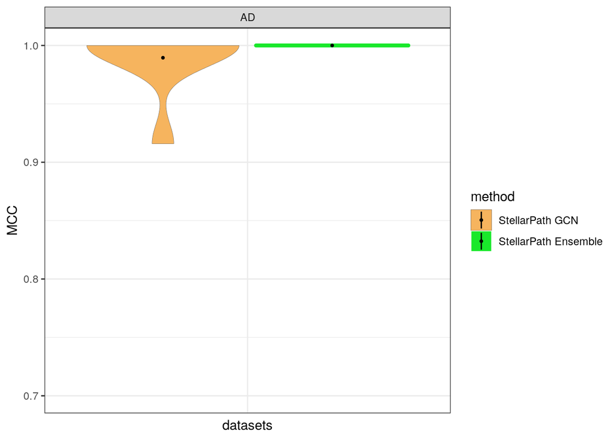

```r
#Prepare data about classification performances ----
#Extract and format the classification performance of the GCN with each PSN
perfs=data_l$inference$performances$perfsXpathway_dfs
perfs$method="StellarPath GCN"

#Combine it with the Ensembl performance
ens_perfs=apply(data_l$inference$performances$performances[,3:6],2,as.numeric)
ens_perfs=rbind(ens_perfs,ens_perfs)
ens_perfs1=perfs[1:nrow(ens_perfs),]
ens_perfs1[,c(1,2,3,4,9,10,11)]=NA
ens_perfs1[,5:8]=ens_perfs
ens_perfs1$method="StellarPath Ensemble"
perfs=rbind(perfs,ens_perfs1)
perfs$dataset="AD"

#Prepare the dataframe for the plot
ord_methods=c("StellarPath GCN","StellarPath Ensemble")
perfs$method <- factor(perfs$method ,levels = ord_methods, ordered = TRUE)

#Plot
inf_perf_p=ggplot(perfs, aes(x = dataset, y = test_mcc, fill = method, color = method, size = method)) +
  geom_violin(scale = "width", position = position_dodge(width = 1)) +
  scale_color_manual(values = c("grey30", "#19E82B")) +
  scale_fill_manual(values = c('#f6b45e','#19E82B')) +
  scale_size_manual(values = c(0.1, 1.5)) +
  theme(text = element_text(size = 8)) + theme_bw() +
  labs(y = "MCC", x = "datasets") +
  facet_grid(~ dataset, scales = "free") +
  theme(axis.ticks.x = element_blank(), axis.text.x = element_blank()) +
  ylim(0.7, 1) +
  stat_summary(fun.y = mean, mult = 1,
               geom = "pointrange", color = "black",
               position = position_dodge2(preserve = "single", 1, padding = 0.1), size = 0.02)

#Print
inf_perf_p
```

[output not shown]

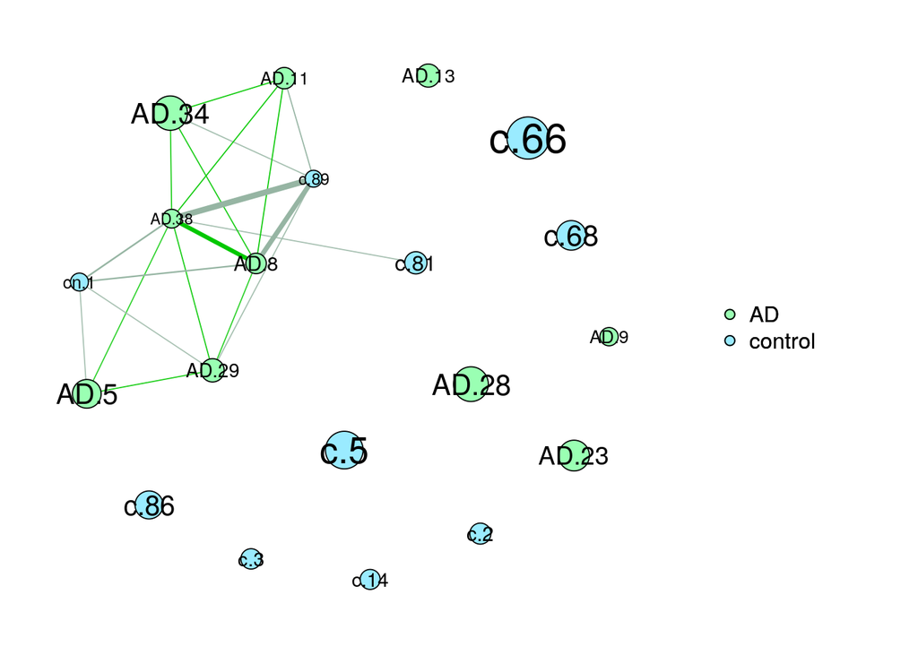

```r
#Get the pathway's data
data2plot=get_pathway_data(data_l$inference,path2path = "enrichment$omics$gex$pathway_analysis$top_pathways_l$CHEMOKINE-MEDIATED SIGNALING PATHWAY")
#Get the info and PSN
info_inf=data_l$inference$run1$testing$info
PSN=data2plot$PSN
#Plot
PSN_plot=plot_PSN(info_inf, PSN, edge_threshold = 0.5, k_clusters = 10, GLratio=3, file_path = "AD")
```

```r
#Subgroup of nodes
PSN_subs=utils::stack(PSN_plot$names_in_k_l)
```

We export plots and results

```r
#Save
usage_plot = ggpubr::ggarrange(cv_paths_p, inf_perf_p, labels = c("A", "B"), ncol = 1, nrow = 2)

ggsave(filename=out_plot_path, plot=usage_plot,
       width = 170, height=130, units="mm",
       dpi = 600, version="1.5")
ggsave(filename=gsub("pdf","png",out_plot_path), plot=usage_plot,
       width = 170, height=130, units="mm",
       dpi = 600)

#Report all the info
wr_l=list()
#Pathways found during cv training and testing
wr_l[["AD_pathways"]]=data_l$enrichment$pathway_analysis$top_pathways_df
#Performance of the pathways used for the inference
wr_l[["AD_perfs"]]=data_l$inference$performances$perfsXpathway_dfs
#Likelihood of how many pathway-specific PSNs/GCN predicted correctly each patient
wr_l[["AD_likelihood"]]=data_l$inference$run1$testing$info
#Subnodes in the PSN
wr_l[["PSN_data"]]=PSN_subs
#Write
writexl::write_xlsx(wr_l, path = out_perfs_path)
```